# Analyses exploratoire des données Lapage

#### - Lien entre l'âge des clients et le montant total des achats

##### Teste de correlation entre 2 variables quantitatives (**age** - **montant total**) -> Test à determiner :

##### Commençons par visualiser ces 2 variables

```python
#Création des variables necessaire à l'affichage de la regression linaire - Méthode des moindres carrés (OLS)
slope, intercept, r_value, p_value, std_er = st.linregress(df_tranches_ageCA["age"],df_tranches_ageCA["CA_total"])

def predict(x):
   return slope * x + intercept
```

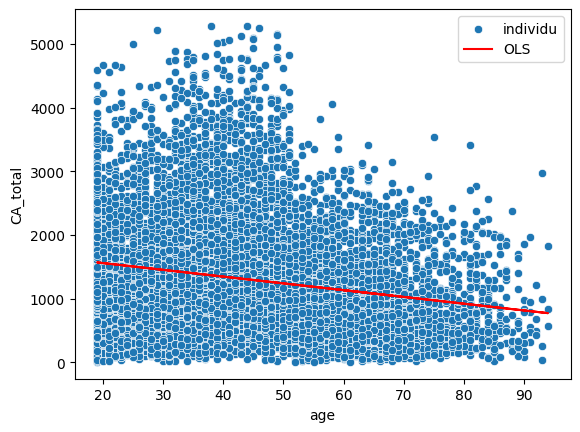

```python
#Affichage graphique
sns.scatterplot(data=df_tranches_ageCA, x="age", y="CA_total")

regress_lin(df_tranches_ageCA["age"],df_tranches_ageCA["CA_total"])

plt.legend(["individu","OLS"])

plt.show()
```

Correlation légère et négative à première vue -> le CA_total maximum semble diminuer avec l'age

##### Vérification et clarification par le biais de tranches d'age

```python
df_tranches_ageCA.head()
```

|  | client_id | age | CA_total | tranche_age |
| --- | --- | --- | --- | --- |
| 0 | c_1 | 68.0 | 629.02 | 4 |
| 1 | c_10 | 67.0 | 1353.60 | 4 |
| 2 | c_100 | 31.0 | 254.85 | 1 |
| 3 | c_1000 | 57.0 | 2291.88 | 3 |
| 4 | c_1001 | 41.0 | 1823.85 | 2 |

```python
df_tranches_ageCA["tranche_age"].unique()
```

```
array([4, 1, 3, 2, 5], dtype=int64)
```

```python
#Récupération des ages concernés par les tranches pour plus de lisibilité
tranches = []

for t in sorted(df_tranches_ageCA["tranche_age"].unique()):
    age_mini = int(df_tranches_ageCA.loc[df_tranches_ageCA["tranche_age"] == t, "age"].min())
    age_max = int(df_tranches_ageCA.loc[df_tranches_ageCA["tranche_age"] == t, "age"].max())

    tranches.append(str(age_mini)+"-"+str(age_max))

tranches
```

```
['19-34', '35-50', '51-66', '67-82', '83-94']
```

```python
# Assignation des tranches d'ages
for t in sorted(df_tranches_ageCA["tranche_age"].unique()):
    df_tranches_ageCA.loc[df_tranches_ageCA["tranche_age"] == t, "tranche_age"] = tranches[t-1]
```

```python
df_tranches_ageCA.sort_values("tranche_age", ascending=True, inplace=True)
```

```python
#Création d'un dictionnaire du nombre d'effectif par tranche
groupes = []
for tranche in sorted(df_tranches_ageCA["tranche_age"].unique()):
    nb_clients = df_tranches_ageCA.loc[df_tranches_ageCA["tranche_age"] == tranche]["tranche_age"].count()

    groupes.append(nb_clients)
```

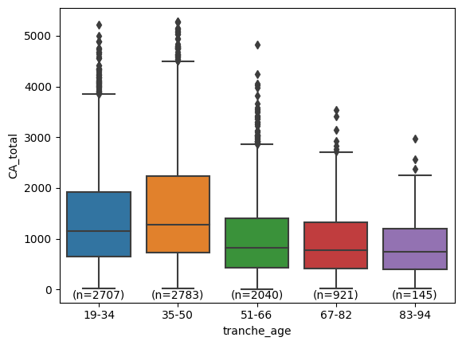

```python
#Représentation graphique
sns.boxplot(df_tranches_ageCA, x="tranche_age", y="CA_total")

i=0
for g in groupes:
    plt.text(i,0,"(n={})".format(g), horizontalalignment='center', verticalalignment='top')
    i+=1
plt.show()
```

##### Visualisation de la distribution des 2 variables (suivent-elles une loi normale) :

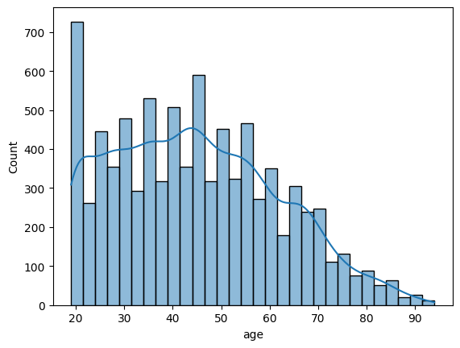

```python
sns.histplot(data=df_tranches_ageCA["age"], kde=True)
```

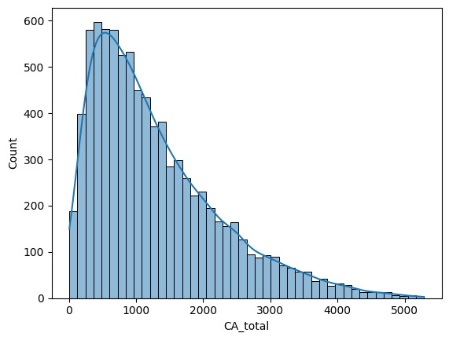

```python
sns.histplot(data=df_tranches_ageCA["CA_total"], kde=True)
```

Les 2 variables ne suivent visuellement pas de loi normale  
Vérifions à l'aide du test de Shapiro (quantité d'individu de taille moyenne):

Test de Shapiro-Wilk sur chacune des 2 variables :

- Conditions de validité :
  - les 2 variables sont quantitatives
  - loi normale **non-necessaire**
  - taille d'échantillon petite ou moyenne
- Hypothèses :
  - nulle H0: La variable **suit** une loi normale
  - alternative H1: La variable **ne suit pas** une loi normale

```python
for var in [df_tranches_ageCA["age"], df_tranches_ageCA["CA_total"]]:
    shapiro_value, p_value = st.shapiro(var)

    print("La p-value est de la variable {} est de : {} ".format(var.name, p_value))
```

```
La p-value est de la variable age est de : 4.628808323714737e-39
La p-value est de la variable CA_total est de : 0.0
```

Conclusion :

- Les p-value des 2 variables sont nettement inférieurs au seuil de 0.05 (seuil conventionnel de risque accepté)
  - **Les 2 variables ne suivent pas une loi normale**

##### Nous ne pouvons pas utiliser le test de Pearson (paramétrique) -> Test de Spearman :

- Conditions de validité :
  - les 2 variables sont quantitatives
  - loi normale **non-necessaire**
- Hypothèses p-value:
  - nulle H0: Il **n'y a pas de corrélation monotone ** entre l'age et le panier total (indépendance)
  - alternative H1: Il **y a une corrélation monotone** entre l'age et le panier total (dépendance)
- Risque accepté : 5%
- Intensité et sens de corrélation indiqué par le coefficient spearman_r
  - spearman_r = 0 -> pas de corrélation
  - 1 > spearman_r > 0 -> corrélation positive
  - 0 > spearman_r > -1 -> corrélation négative

  À nuancer avec le graphique de début

```python
spearman_r, p_value = st.spearmanr(df_tranches_ageCA["age"],df_tranches_ageCA["CA_total"])
covar = np.cov(df_tranches_ageCA["age"],-df_tranches_ageCA["CA_total"],ddof=0)

print("Le coefficient de Spearman est de {}".format(round(spearman_r, 3)))
print("La p-value est de {}".format(p_value))
```

```
Le coefficient de Spearman est de -0.185
La p-value est de 1.0211908275536399e-66
```

Force de la corrélation:

0.0 < 0.1 pas de corrélation

0.1 < 0.3 faible corrélation

0.3 < 0.5 corrélation moyenne

0.5 < 0.7 corrélation élevée

0.7 < 1 corrélation très élevée

[Source déterminant la force et la direction de la correlation](https://datatab.fr/tutorial/pearson-correlation)

Conclusion :

- spearman_r = -0.19 = **faible corrélation (inversée)** plus l'age augmente plus le montant total diminue
- p-value < 0.05* (seuil conventionnel) = **correlation significative**

#### - Lien entre l'âge des clients et la fréquence d’achat

##### Commençons par visualiser ces 2 variables :

```python
#Création du dataframe sur le nombre d'achat par client
df_temp = df_btoc.groupby(["client_id", "age","session_id"]).agg(livres_session=("session_id","count")).reset_index()

df_age_freq = df_temp.groupby(["client_id", "age"]).agg(session_total=("livres_session","count")).reset_index()

df_age_freq.head()
```

|  | client_id | age | session_total |
| --- | --- | --- | --- |
| 0 | c_1 | 68 | 34 |
| 1 | c_10 | 67 | 34 |
| 2 | c_100 | 31 | 5 |
| 3 | c_1000 | 57 | 94 |
| 4 | c_1001 | 41 | 47 |

```python
df_verif = df_btoc.groupby(["client_id","session_id"]).agg(session_total=("session_id","count")).reset_index()

df_verif.loc[df_verif["client_id"]=="c_100"]
```

|  | client_id | session_id | session_total |
| --- | --- | --- | --- |
| 68 | c_100 | s_23060 | 1 |
| 69 | c_100 | s_240961 | 1 |
| 70 | c_100 | s_270695 | 1 |
| 71 | c_100 | s_53051 | 2 |
| 72 | c_100 | s_73929 | 3 |

```python
#Affichage de la fréquence d'achat global
nb_clients = df_age_freq["client_id"].count()
nb_session = df_age_freq["session_total"].sum()

freq_globale = round(nb_session/nb_clients, 2) #similaire à df_age_freq["session_total"].mean()

freq_globale
```

```
37.51
```

Un client fait en moyenne 37.5 commandes

```python
#Création de la colonne de fréquence -> nombre de session / nombre total de session
df_age_freq["freq_client"] = df_age_freq["session_total"]/df_age_freq["session_total"].sum()
```

```python
#Récupération des tranches d'ages
df_age_freq = df_age_freq.merge(df_tranches_ageCA[["client_id", "tranche_age"]], on="client_id")
```

```python
df_age_freq.head()
```

|  | client_id | age | session_total | freq_client | tranche_age |
| --- | --- | --- | --- | --- | --- |
| 0 | c_1 | 68 | 34 | 0.000105 | 67-82 |
| 1 | c_10 | 67 | 34 | 0.000105 | 67-82 |
| 2 | c_100 | 31 | 5 | 0.000016 | 19-34 |
| 3 | c_1000 | 57 | 94 | 0.000292 | 51-66 |
| 4 | c_1001 | 41 | 47 | 0.000146 | 35-50 |

```python
#Création d'un dictionnaire du nombre d'effectifs par tranche
groupes = []
for tranche in sorted(df_age_freq["tranche_age"].unique()):
    nb_clients = df_age_freq.loc[df_age_freq["tranche_age"] == tranche]["tranche_age"].count()

    groupes.append(nb_clients)
```

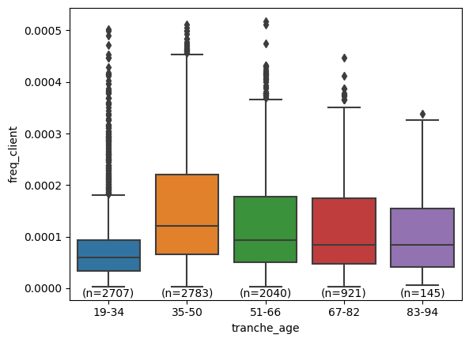

```python
data = df_age_freq.sort_values("tranche_age", ascending=True)
x = "tranche_age"
y = "freq_client"

sns.boxplot(data=data , x="tranche_age", y="freq_client")

i=0
for g in groupes:
    plt.text(i,0,"(n={})".format(g), horizontalalignment='center', verticalalignment='top')
    i+=1
plt.show()
```

Nous savons d'avance que la variable **age** ne suit pas une loi normale

##### Nous ne pouvons pas utiliser le test de Pearson (paramétrique) -> Test de Spearman :

- Conditions de validité :
  - les 2 variables sont quantitatives
  - loi normale **non-necessaire**
- Hypothèses p-value:
  - nulle H0: Il **n'y a pas de corrélation monotone** entre l'age et la fréquence d'achat (indépendance)
  - alternative H1: Il **y a une corrélation monotone** entre l'age et la fréquence d'achat (dépendance)
- Risque accepté : 5%
- Intensité et sens de corrélation indiqué par le coefficient spearman_r
  - spearman_r = 0 -> pas de corrélation
  - 1 > spearman_r > 0 -> corrélation positive
  - 0 > spearman_r > -1 -> corrélation négative À nuancer avec le graphique de début

```python
spearman_r, p_value = st.spearmanr(df_age_freq["age"], df_age_freq["freq_client"])

print("Le coefficient de Spearman est de {}".format(round(spearman_r, 3)))
print("La p-value est de {}".format(p_value))
```

```
Le coefficient de Spearman est de 0.212
La p-value est de 6.629168433162815e-88
```

Force de la corrélation:

0.0 < 0.1 pas de corrélation

0.1 < 0.3 faible corrélation

0.3 < 0.5 corrélation moyenne

0.5 < 0.7 corrélation élevée

0.7 < 1 corrélation très élevée

[Source déterminant la force et la direction de la correlation](https://datatab.fr/tutorial/pearson-correlation)

Conclusion préliminaire:

- spearman_r = + 0.21 = **faible corrélation positive** plus l'age augmente plus la frequence d'achats augmente
- p-value < 0.05 (seuil conventionnel) = **H0 rejeté** -> resultat significatif

Ce résultat est étonnant au vu du boxplot au dessus, vérifions en groupant les ages avec leur moyenne de fréquence :

```python
#Création du data frame necessaire
df_test= df_age_freq.groupby("age")["freq_client"].mean().reset_index()
df_test.head()
```

|  | age | freq_client |
| --- | --- | --- |
| 0 | 19 | 0.000062 |
| 1 | 20 | 0.000056 |
| 2 | 21 | 0.000057 |
| 3 | 22 | 0.000062 |
| 4 | 23 | 0.000056 |

```python
#Création des variables necessaire à l'affichage de la regression linaire - Méthode des moindres carrés (OLS)
slope, intercept, r_value, p_value, std_er = st.linregress(df_test["age"],df_test["freq_client"])

def predict(x):
   return slope * x + intercept
```

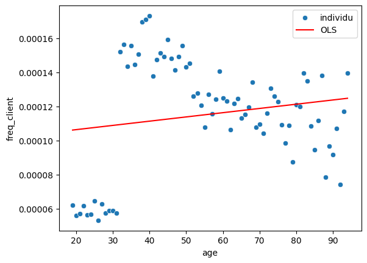

```python
sns.scatterplot(data=df_test, x="age", y="freq_client")
regress_lin(df_test["age"],df_test["freq_client"])

plt.legend(["individu","OLS"])
```

En effet, le résultat confirme l'hypothèse vu sur le boxplot : il semble y avoir une corrélation négative à partir de 32 ans environs et faussée par le premier groupe  
Vérifion en isolant les 2 groupes (19-à définir | à définir-94ans):

```python
#Determinons l'age bascule (autour des 32 ans) où toutes les premières valeurs sont supérieures à la moyenne des valeurss (choisi arbitrairement)
agemini_groupe_valide = df_test.loc[df_test["freq_client"] > df_test["freq_client"].mean()]["age"].min()
```

```python
#Création du nouveau dataframe avec le bon groupe d'individu
df_groupe_valide = df_age_freq.loc[df_age_freq["age"] >= agemini_groupe_valide]
```

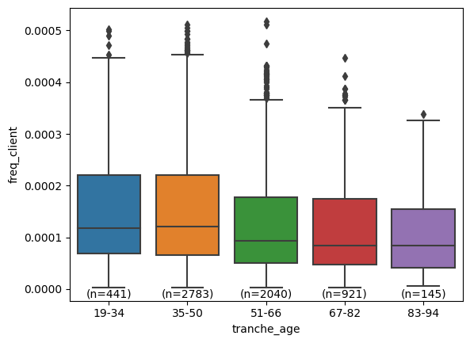

```python
groupes = []
for tranche in sorted(df_groupe_valide["tranche_age"].unique()):
    nb_clients = df_groupe_valide.loc[df_groupe_valide["tranche_age"] == tranche]["tranche_age"].count()

    groupes.append(nb_clients)

sns.boxplot(data=df_groupe_valide.sort_values("age", ascending=True), x="tranche_age", y="freq_client")
i=0
for g in groupes:
    plt.text(i,0,"(n={})".format(g), horizontalalignment='center', verticalalignment='top')
    i+=1
plt.show()
```

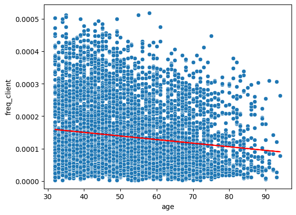

```python
sns.scatterplot(data=df_groupe_valide, x="age", y="freq_client")
regress_lin(df_groupe_valide["age"],df_groupe_valide["freq_client"])
plt.show()
```

```python
spearman_r, p_value = st.spearmanr(df_groupe_valide["age"], df_groupe_valide["freq_client"])

print("Le coefficient de Spearman est de {} sur les individus de {} à {} ans".format(round(spearman_r, 3), agemini_groupe_valide,df_groupe_valide["age"].max() ))
print("La p-value est de {}".format(p_value))
```

```
Le coefficient de Spearman est de -0.148 sur les individus de 32 à 94 ans
La p-value est de 3.6670140717793306e-32
```

Conclusion finale:

Sur les 32-94 ans

- Coefficient de Spearman = -0.15 -> **corrélation faible et négative** entre l'age et la fréquence d'achat
- p-value fiable à 99% -> **H0 rejeté** -> test significatif

#### - Lien entre l'âge des clients et la taille du panier moyen

##### Commençons par visualiser ces 2 variables :

```python
#Création d'un premier dataframe avec les paniers pour chaque client
df_panier = df_btoc.groupby(["client_id", "age", "session_id"]).agg(CA_session=("price","sum")).reset_index()

df_panier.head()
```

|  | client_id | age | session_id | CA_session |
| --- | --- | --- | --- | --- |
| 0 | c_1 | 68 | s_101417 | 15.87 |
| 1 | c_1 | 68 | s_105105 | 62.96 |
| 2 | c_1 | 68 | s_114737 | 92.62 |
| 3 | c_1 | 68 | s_120172 | 44.29 |
| 4 | c_1 | 68 | s_134971 | 10.30 |

```python
#Création du dataframe aggrégé sur les clients
df_panier_moy = df_panier.groupby(["client_id", "age"]).agg(nb_paniers=("session_id","count"), CA_total_paniers=("CA_session","sum")).reset_index()

df_panier_moy.head()
```

|  | client_id | age | nb_paniers | CA_total_paniers |
| --- | --- | --- | --- | --- |
| 0 | c_1 | 68 | 34 | 629.02 |
| 1 | c_10 | 67 | 34 | 1353.60 |
| 2 | c_100 | 31 | 5 | 254.85 |
| 3 | c_1000 | 57 | 94 | 2291.88 |
| 4 | c_1001 | 41 | 47 | 1823.85 |

```python
#Création de la colonne avec le panier moyen (CA / nb de panier)
df_panier_moy["panier_moyen"] = df_panier_moy["CA_total_paniers"] / df_panier_moy["nb_paniers"]
```

```python
#Rapprochement des tranches d'ages
df_panier_moy = df_panier_moy.merge(df_tranches_ageCA[["client_id", "tranche_age"]], on="client_id")
```

```python
df_panier_moy.head()
```

|  | client_id | age | nb_paniers | CA_total_paniers | panier_moyen | tranche_age |
| --- | --- | --- | --- | --- | --- | --- |
| 0 | c_1 | 68 | 34 | 629.02 | 18.500588 | 67-82 |
| 1 | c_10 | 67 | 34 | 1353.60 | 39.811765 | 67-82 |
| 2 | c_100 | 31 | 5 | 254.85 | 50.970000 | 19-34 |
| 3 | c_1000 | 57 | 94 | 2291.88 | 24.381702 | 51-66 |
| 4 | c_1001 | 41 | 47 | 1823.85 | 38.805319 | 35-50 |

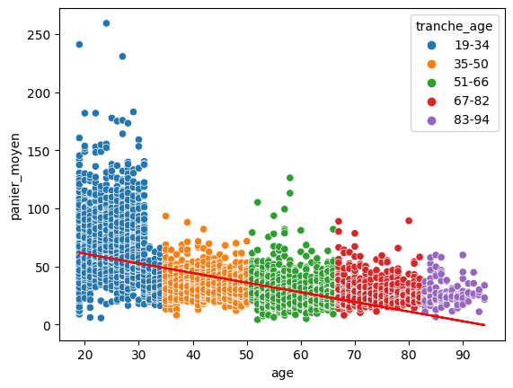

```python
sns.scatterplot(data=df_panier_moy.sort_values("age",ascending=True), x="age", y="panier_moyen", hue="tranche_age")
regress_lin(df_panier_moy["age"], df_panier_moy["panier_moyen"])
```

Premier aperçu: les 19-32 ans on un panier moyen nettement supérieur aux autres tranches d'ages ce qui a un impact sur la corrélation qui sera potentiellement fortement négative

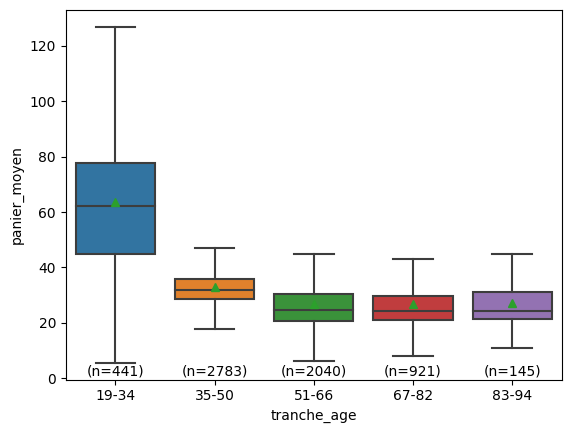

```python
sns.boxplot(df_panier_moy.sort_values("age",ascending=True), x="tranche_age", y="panier_moyen", showmeans=True, showfliers = False )

i=0
for g in groupes:
    plt.text(i,5,"(n={})".format(g), horizontalalignment='center', verticalalignment='top')
    i+=1
plt.show()
```

##### Nous ne pouvons pas utiliser le test de Pearson (paramétrique) -> Test de Spearman :

- Conditions de validité :
  - les 2 variables sont quantitatives
  - loi normale **non-necessaire**
- Hypothèses p-value:
  - nulle H0: Il **n'y a pas de corrélation monotone** entre l'age et la fréquence d'achat (indépendance)
  - alternative H1: Il **y a une corrélation monotone** entre l'age et la fréquence d'achat (dépendance)
- Risque accepté : 5%
- Intensité et sens de corrélation indiqué par le coefficient spearman_r
  - spearman_r = 0 -> pas de corrélation
  - 1 > spearman_r > 0 -> corrélation positive
  - 0 > spearman_r > -1 -> corrélation négative À nuancer avec le graphique de début

```python
spearman_r, p_value= st.spearmanr(df_panier_moy["age"],df_panier_moy["panier_moyen"])

print("Le coefficient de spearman est de {}".format(round(spearman_r, 3)))
print("La p-value est de {}".format(p_value))
```

```
Le coefficient de spearman est de -0.701
La p-value est de 0.0
```

Conclusion :

- spearman_r = - 0.70 = **forte corrélation négative** -> plus l'age augmente plus le panier moyen diminu
- p-value = 0 < 0.05* (seuil conventionnel) = **H0 rejeté** -> test significative -> variables dépendantes

Force de la corrélation:

0.0 < 0.1 pas de corrélation

0.1 < 0.3 faible corrélation

0.3 < 0.5 corrélation moyenne

0.5 < 0.7 corrélation élevée

0.7 < 1 corrélation très élevée

[Source déterminant la force et la direction de la correlation](https://datatab.fr/tutorial/pearson-correlation)

##### Vérifion cette corrélation en ne prenant pas en compte le groupe jeune (19-32ans)

```python
#Création du df concerné
df_groupe_valide = df_panier_moy.loc[df_panier_moy["age"] >= agemini_groupe_valide]
df_groupe_valide.min()
```

```
client_id             c_1
age                    32
nb_paniers              1
CA_total_paniers     6.31
panier_moyen         4.15
tranche_age         19-34
dtype: object
```

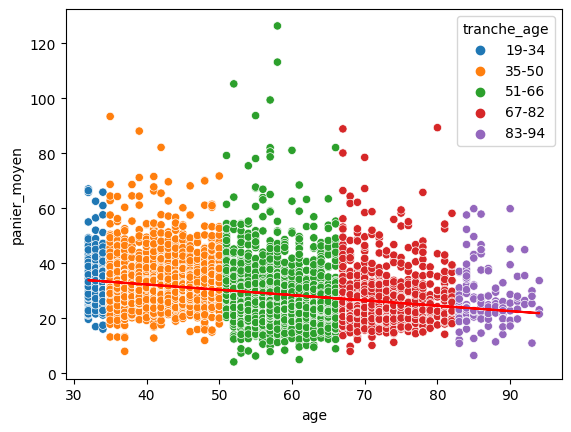

```python
sns.scatterplot(data=df_groupe_valide.sort_values("age",ascending=True), x="age", y="panier_moyen", hue="tranche_age")
regress_lin(df_groupe_valide["age"], df_groupe_valide["panier_moyen"])
```

```python
spearman_r, p_value= st.spearmanr(df_groupe_valide["age"],df_groupe_valide["panier_moyen"])

print("Le coefficient de Pearson est de {}".format(round(spearman_r, 3)))
print("La p-value est de {}".format(p_value))
```

```
Le coefficient de Pearson est de -0.402
La p-value est de 1.2270547101185366e-244
```

Conclusion finale :  
Sur les 32-94 ans

- Spearman_r = - 0.40 -> **corrélation négative d'intensité moyenne**
- p-value fiable à 99% -> **H0 rejeté** -> test statistique fiable

#### - Lien entre l'âge des clients et la catégorie des livres achetés

##### Commençons par visualiser ces 3 variables :

```python
#Création du dataframe concerné
x = "categ"
y = "age"

df_age_cat = df_btoc[[x,y]]
```

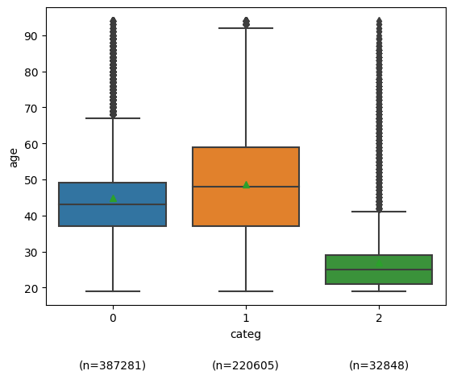

```python
sns.boxplot(df_age_cat, x="categ", y="age", showfliers=True, showmeans=True)

i=0
for cat in sorted(df_age_cat["categ"].unique()):
    n_cat = len(df_age_cat.loc[df_age_cat["categ"] == cat])

    plt.text(i,0,"(n={})".format(n_cat), horizontalalignment='center', verticalalignment='top')
    i+=1

plt.show()
```

Les 3 catégories semblent assez différentes, même si l'ordre de grandeur de ces écarts n'est pas très grand, la question est de savoir si ces écarts sont significatifs ou pas.

*C'est l'ANOVA qui nous permettra de répondre à cette question.*

##### Teste d'association entre une variable quantitative et 1 variables qualitatives (**age** - **categ**) -> Test ANOVA :

([OneWay ANOVA](https://www.kaggle.com/code/hamelg/python-for-data-26-anova/notebook))

- Conditions de validité :
  - une variable est **quantitative**
  - une variable est **qualitatives**
  - plus de 2 modalités
  - les individus sont indépendants
  - égalité des variances entre les modalités (à vérifier)
  - loi normale
- Hypothèses p-value:
  - nulle H0: Les moyennes de **tous les groupes sont égales** entre l'age et les catégories (variables non associées)
  - alternative H1: La moyenne de **au moins 1 groupe est significativement différent** entre l'age et les catégories (certaines variables associées)
- Risque accepté : 5%

```python
len(df_age_cat)
```

```
640734
```

Je sais que la variable quantitative **age** ne suit pas une loi normale

*Vaudor L (2015). “Non-respect des hypothèses du modèle linéaire (ANOVA, régression): c'est grave, docteur??”*

```python
#Création des variables par categorie
cat_0 = df_age_cat.loc[df_age_cat["categ"] == 0]["age"]
cat_1 = df_age_cat.loc[df_age_cat["categ"] == 1]["age"]
cat_2 = df_age_cat.loc[df_age_cat["categ"] == 2]["age"]
```

```python
#ANOVA test
st.f_oneway(cat_0, cat_1, cat_2)
```

```
F_onewayResult(statistic=39705.51969324281, pvalue=0.0)
```

Conclusion :

- p-value < 5% -> **H0 rejeté** -> l'age a bien un effet sur au moins une catégorie de livres achetés

##### La vérification de ce test ce valide suivant ces différentes hypothèses:

l’indépendance entre les échantillons de chaque groupe

l’égalité des variances | Test de Levene (car pas de variable suivant une loi normale)

la normalité des résidus | Test de Shapiro -> inutile avec autant d'individus

##### L'indépendance :

Il y a bien une indépendance entre les catégories 0, 1 et 2

##### L'égalité des variances :

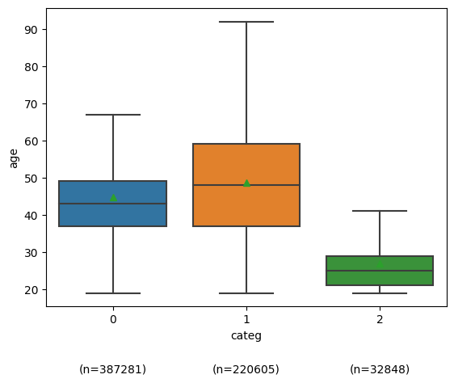

```python
sns.boxplot(df_age_cat, x="categ", y="age", showfliers=False, showmeans=True)

i=0
for cat in sorted(df_age_cat["categ"].unique()):
    n_cat = len(df_age_cat.loc[df_age_cat["categ"] == cat])

    plt.text(i,0,"(n={})".format(n_cat), horizontalalignment='center', verticalalignment='top')
    i+=1

plt.show()
```

```python
#Création d'un dataframe pour vérifier si les variances sont égales
df_age_cat.groupby("categ")['age'].agg('var')
```

```
categ
0    132.620783
1    250.414686
2     98.007304
Name: age, dtype: float64
```

Vérification si les variances sont significativement différentes avec le test de Levene (distribution non Gaussienne) :

H0 : Les variances de chaque groupe sont égales si p-value > 5%

H1 : La variances d'au moins un groupe n'est pas égale au autres < 5%

```python
cat_0 = df_btoc["age"][df_btoc["categ"] == 0]
cat_1 = df_btoc["age"][df_btoc["categ"] == 1]
cat_2 = df_btoc["age"][df_btoc["categ"] == 2]
st.levene(cat_0, cat_1, cat_2)
```

```
LeveneResult(statistic=24651.780367284304, pvalue=0.0)
```

Conclusion :

- p-value fiable à 99% -> H0 rejeté -> il y a au moins un groupe qui à une variance différente
- **Pas d'égalité des variances** -> Test de Kruskal-Wallis (test non-paramétrique) necessaire

##### Test final de Kruskal-Wallis

- Conditions de validité :
  - une variable est **quantitative**
  - une variable est **qualitatives**
  - plus de 2 modalités
  - loi normale **non-necessaire**
- Hypothèses p-value:
  - nulle H0: La médiane de **tous les groupes sont égales** entre l'age et les catégories (variables non associées)
  - alternative H1: La médiane de **au moins 1 groupe est significativement différent** entre l'age et les catégories (certaines variables associées)
- Risque accepté : 5%

```python
st.kruskal(cat_0, cat_1, cat_2)
```

```
KruskalResult(statistic=71359.73412120914, pvalue=0.0)
```

Conclusion :

- p-value = 0 < 0.5 -> H0 rejeté -> Il y a une différence de médiane entre au moins 2 groupe et par conséquence il y a une association entre l'age et la catégorie de livre choisi

#### Optionnel pour la présentation powerpoint

##### Proportion catégorie / tranche d'age

```python
#Création d'un dataframe pour visualiser des informations sur powerpoint -> proportion catégorie par tranche d'age
df_temp = df_btoc.merge(df_age_freq[["client_id","tranche_age"]], on="client_id")

df_temp.head()
```

|  | client_id | date | monthly | session_id | id_prod | price | categ | age | sex | jour | heure | tranche_age |
| --- | --- | --- | --- | --- | --- | --- | --- | --- | --- | --- | --- | --- |
| 0 | c_329 | 2021-03-01 | 2021-03-01 | s_1 | 0_1259 | 11.99 | 0 | 56 | f | Monday | 00 | 51-66 |
| 1 | c_329 | 2022-10-01 | 2022-10-01 | s_275943 | 0_1259 | 11.99 | 0 | 56 | f | Saturday | 00 | 51-66 |
| 2 | c_329 | 2022-12-01 | 2022-12-01 | s_305291 | 0_1259 | 11.99 | 0 | 56 | f | Thursday | 00 | 51-66 |
| 3 | c_329 | 2023-01-01 | 2023-01-01 | s_320153 | 0_1259 | 11.99 | 0 | 56 | f | Sunday | 00 | 51-66 |
| 4 | c_329 | 2021-11-23 | 2021-11-01 | s_123998 | 1_397 | 18.99 | 1 | 56 | f | Tuesday | 18 | 51-66 |

```python
df_tempT = df_temp.pivot_table(index="tranche_age", values="price", aggfunc="count", columns="categ").reset_index()
df_tempT.head()
```

| categ | tranche_age | 0 | 1 | 2 |
| --- | --- | --- | --- | --- |
| 0 | 19-34 | 55809 | 42164 | 30100 |
| 1 | 35-50 | 248250 | 80318 | 1190 |
| 2 | 51-66 | 58422 | 65062 | 1037 |
| 3 | 67-82 | 21550 | 28838 | 441 |
| 4 | 83-94 | 3250 | 4223 | 80 |

##### Proportion CA / tranche d'age | age

```python
df_tranches_ageCA
```

|  | client_id | age | CA_total | tranche_age |
| --- | --- | --- | --- | --- |
| 6086 | c_6491 | 27.0 | 302.71 | 19-34 |
| 2295 | c_3068 | 33.0 | 664.12 | 19-34 |
| 7664 | c_7916 | 19.0 | 487.36 | 19-34 |
| 4675 | c_5218 | 26.0 | 684.68 | 19-34 |
| 4674 | c_5217 | 19.0 | 2039.50 | 19-34 |
| ... | ... | ... | ... | ... |
| 5285 | c_577 | 94.0 | 1829.96 | 83-94 |
| 7173 | c_7473 | 87.0 | 1434.75 | 83-94 |
| 5306 | c_5789 | 84.0 | 1151.39 | 83-94 |
| 401 | c_1360 | 89.0 | 1643.92 | 83-94 |
| 8159 | c_8362 | 94.0 | 842.87 | 83-94 |

8596 rows × 4 columns

```python
#Top CA
df_temp = df_tranches_ageCA.groupby("age").agg(panier_moyen=("CA_total","mean"),nb_client=("client_id","count")).sort_values("panier_moyen", ascending=False)
df_temp.head()
```

| age | panier_moyen | nb_client |
| --- | --- | --- |
| 39.0 | 1769.851677 | 155 |
| 40.0 | 1765.272469 | 162 |
| 38.0 | 1705.251739 | 115 |
| 45.0 | 1655.286131 | 199 |
| 49.0 | 1633.616625 | 160 |

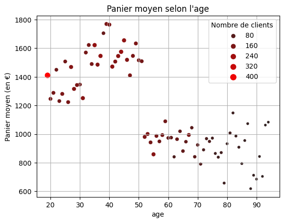

```python
sns.scatterplot(df_temp, x="age", y="panier_moyen", hue="nb_client", size="nb_client", palette="dark:red")

plt.ylabel("Panier moyen (en €)")
plt.title("Panier moyen selon l'age")
plt.legend(title="Nombre de clients")
plt.grid(which="both")
```

```python
#Flop CA
df_tranches_ageCA.groupby("age").agg(CA_total=("CA_total","sum")).sort_values("CA_total", ascending=True).head()
```

| age | CA_total |
| --- | --- |
| 92.0 | 2815.45 |
| 94.0 | 3249.84 |
| 93.0 | 4251.22 |
| 88.0 | 4945.03 |
| 91.0 | 5059.18 |

```python
df_tranches_ageCA.groupby("tranche_age").agg(CA_total=("CA_total","sum"))
```

| tranche_age | CA_total |
| --- | --- |
| 19-34 | 3732990.03 |
| 35-50 | 4386638.92 |
| 51-66 | 2041793.00 |
| 67-82 | 854416.21 |
| 83-94 | 127528.85 |

##### Proportion volume / age

```python
#Création d'un dataframe pour visualiser des informations sur powerpoint -> proportion catégorie par tranche d'age
df_temp = df_btoc.merge(df_age_freq[["client_id","tranche_age"]], on="client_id")

df_temp.head()
```

|  | client_id | date | monthly | session_id | id_prod | price | categ | age | sex | jour | heure | tranche_age |
| --- | --- | --- | --- | --- | --- | --- | --- | --- | --- | --- | --- | --- |
| 0 | c_329 | 2021-03-01 | 2021-03-01 | s_1 | 0_1259 | 11.99 | 0 | 56 | f | Monday | 00 | 51-66 |
| 1 | c_329 | 2022-10-01 | 2022-10-01 | s_275943 | 0_1259 | 11.99 | 0 | 56 | f | Saturday | 00 | 51-66 |
| 2 | c_329 | 2022-12-01 | 2022-12-01 | s_305291 | 0_1259 | 11.99 | 0 | 56 | f | Thursday | 00 | 51-66 |
| 3 | c_329 | 2023-01-01 | 2023-01-01 | s_320153 | 0_1259 | 11.99 | 0 | 56 | f | Sunday | 00 | 51-66 |
| 4 | c_329 | 2021-11-23 | 2021-11-01 | s_123998 | 1_397 | 18.99 | 1 | 56 | f | Tuesday | 18 | 51-66 |

```python
df_temp = df_temp.groupby("age").agg(nb_book=("price","count"))
df_temp.sort_values("nb_book",ascending=False).head()
```

| age | nb_book |
| --- | --- |
| 35 | 25245 |
| 44 | 25101 |
| 45 | 24905 |
| 37 | 23693 |
| 43 | 22116 |

```python
df_temp.sort_values("nb_book",ascending=True).head()
```

| age | nb_book |
| --- | --- |
| 92 | 170 |
| 94 | 202 |
| 93 | 238 |
| 88 | 278 |
| 91 | 312 |

##### Précisions B2B

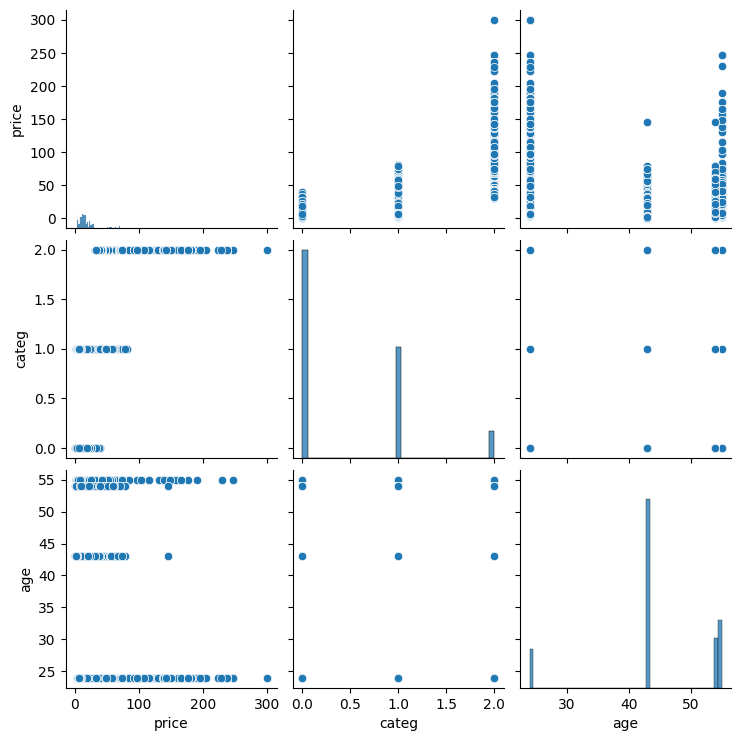

```python
sns.pairplot(data=df_btob)
```

```python
df_btob.head()
```

|  | date | monthly | session_id | id_prod | price | categ | client_id | age | sex |
| --- | --- | --- | --- | --- | --- | --- | --- | --- | --- |
| 84 | 2021-03-04 07:26:01 | 2021-03-01 | s_1519 | 0_1259 | 11.99 | 0 | c_1609 | 43 | m |
| 85 | 2021-06-24 09:40:37 | 2021-06-01 | s_53058 | 0_1259 | 11.99 | 0 | c_1609 | 43 | m |
| 86 | 2021-06-24 14:40:37 | 2021-06-01 | s_53165 | 0_1259 | 11.99 | 0 | c_1609 | 43 | m |
| 87 | 2021-09-26 21:30:08 | 2021-09-01 | s_96014 | 0_1259 | 11.99 | 0 | c_1609 | 43 | m |
| 88 | 2021-10-16 03:22:15 | 2021-10-01 | s_105418 | 0_1259 | 11.99 | 0 | c_1609 | 43 | m |

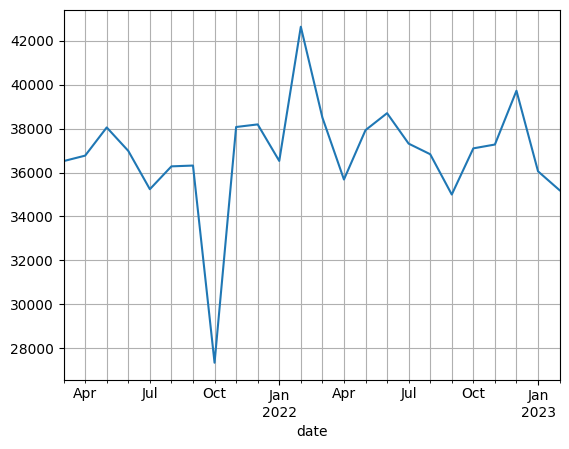

```python
df_btob.set_index("date")["price"].resample("m").sum().plot(kind="line")
plt.grid(which="both")
```

```python
df_custom_btob = df_btob.groupby(["client_id", "session_id", "age"]).agg(
    CA_panier=("price","sum"), nb_book=("price","count")).reset_index()

df_custom_btob.head()
```

|  | client_id | session_id | age | CA_panier | nb_book |
| --- | --- | --- | --- | --- | --- |
| 0 | c_1609 | s_10008 | 43 | 9.04 | 1 |
| 1 | c_1609 | s_100109 | 43 | 23.37 | 2 |
| 2 | c_1609 | s_100157 | 43 | 15.99 | 1 |
| 3 | c_1609 | s_100170 | 43 | 9.80 | 1 |
| 4 | c_1609 | s_100243 | 43 | 48.28 | 4 |

```python
df_custom_btob = df_custom_btob.groupby(["client_id", "age"]).agg(
    nb_session=("session_id","count"),
    CA_total=("CA_panier","sum"),
    panier_moyen=("CA_panier","mean"),
    total_book=("nb_book","sum"),
    nb_book_mean=("nb_book","mean")).reset_index()

df_custom_btob.head()
```

|  | client_id | age | nb_session | CA_total | panier_moyen | total_book | nb_book_mean |
| --- | --- | --- | --- | --- | --- | --- | --- |
| 0 | c_1609 | 43 | 10997 | 326039.89 | 29.648076 | 25586 | 2.326635 |
| 1 | c_3454 | 54 | 5571 | 114110.57 | 20.482960 | 6793 | 1.219350 |
| 2 | c_4958 | 24 | 3851 | 290227.03 | 75.364069 | 5222 | 1.356011 |
| 3 | c_6714 | 55 | 2620 | 153918.60 | 58.747557 | 9199 | 3.511069 |

```python
#Références particulières?
df_btob.groupby("id_prod").agg(
    nb_book=("price","count"),
    CA_total=("price","sum")).sort_values("CA_total",ascending=False).head(5)
```

| id_prod | nb_book | CA_total |
| --- | --- | --- |
| 2_112 | 98 | 6621.86 |
| 2_209 | 89 | 6229.11 |
| 2_110 | 96 | 5976.00 |
| 2_135 | 85 | 5864.15 |
| 2_39 | 96 | 5567.04 |

```python
#Références particulières?
df_btob.groupby("id_prod").agg(
    nb_book=("price","count"),
    CA_total=("price","sum")).sort_values("nb_book",ascending=False).head(5)
```

| id_prod | nb_book | CA_total |
| --- | --- | --- |
| 1_403 | 166 | 2986.34 |
| 1_498 | 160 | 3739.20 |
| 1_395 | 153 | 4435.47 |
| 1_417 | 146 | 3064.54 |
| 1_400 | 141 | 2340.60 |

```python
df_temp = df_btob.groupby("categ").agg(ca_total=("price","sum"), nb_livre=("price","count"), prix_moy_livre=("price","mean"))

df_temp
```

| categ | ca_total | nb_livre | prix_moy_livre |
| --- | --- | --- | --- |
| 0 | 300530.28 | 28178 | 10.665423 |
| 1 | 307555.25 | 14987 | 20.521469 |
| 2 | 276210.56 | 3635 | 75.986399 |

```python
df_temp["ca_total"] = df_temp["ca_total"].round(0)
```

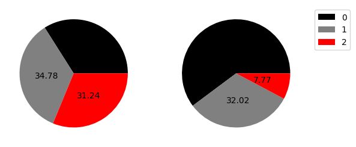

```python
plt.subplot(121)
plt.pie(x=df_temp["ca_total"], autopct="%.2f", pctdistance=0.5, colors=["black", "grey","red"]);

plt.subplot(122)
plt.pie(x=df_temp["nb_livre"], autopct="%.2f", pctdistance=0.5,colors=["black", "grey","red"]);

plt.legend(["0","1","2"], bbox_to_anchor=(1.05, 1))
```